# ds202_lab3

Hanying Shen, and Sijie Huang

10/3/2019

## Background

The General Social Survey (GSS) has been run by NORC every other year since 1972 to keep track of current opinions across the United States. We are working with an excerpt of the dataset that covers years 1972 to 2016. The variable names along with a brief description are as follows:

| Variable | Description |
| --- | --- |
| Year | Year for this respondent |
| Age | Age of respondent |
| Sex | Sex of respondent |
| …. | ….. |

Now it’s important to understand what each column stands for. You can find a codebook with explanations for each of the variables at https://gssdataexplorer.norc.org/

## Data Cleaning

Initial exploration revealed that some data processing was needed before we could proceed with further visualization. All missing values were encoded with ‘NA’ as follows:

```r
library(tidyverse)
happy <- readRDS("HAPPY.rds")
names(happy) = tolower(names(happy))
happy[happy == "IAP"] <- NA
happy[happy == "DK"] <- NA
happy[happy == "NA"] <- NA
names(happy)[sapply(happy, anyNA)]
```

```
## [1] "happy"    "age"      "marital"  "degree"   "finrela"  "health"
## [7] "partyid"  "polviews"
```

```r
sum(is.na(happy))
```

```
## [1] 36391
```

```r
happy<-na.omit(happy)
```

Because missing values will affect the accurace of the analysis and we don’t want to have different code for missing value, we removed all the missing data to avoid errors in making plots and calculations. In total there were `36391` number of missing values for the following `happy`, `age`, `marital`, `degree`, `finrela`, `health`, `partyid` `polviews` variables.

Variables were also cast into the correct type in order to ease data visualization. This was done by:

```r
happy$age<-replace(happy$age,happy$ag=="89 OR OLDER",89)
table(happy$age)
```

```
##
##  18  19  20  21  22  23  24  25  26  27  28  29  30  31  32  33  34  35
## 116 504 539 624 606 745 702 802 765 830 850 783 854 788 829 799 816 792
##  36  37  38  39  40  41  42  43  44  45  46  47  48  49  50  51  52  53
## 823 791 815 706 745 748 702 725 674 634 654 637 645 639 622 613 606 596
##  54  55  56  57  58  59  60  61  62  63  64  65  66  67  68  69  70  71
## 558 523 566 523 565 505 508 500 517 495 402 443 433 464 425 404 388 350
##  72  73  74  75  76  77  78  79  80  81  82  83  84  85  86  87  88  89
## 339 316 314 283 298 254 254 197 204 175 148 148 116 115  97  96  68 186
```

```r
happy$age<-as.numeric(happy$age)
sapply(happy, class)
```

```
##       happy        year         age         sex     marital      degree
## "character"   "integer"   "numeric" "character" "character" "character"
##     finrela      health     wtssall     partyid    polviews
## "character" "character"   "numeric" "character" "character"
```

```r
happy$happy<-as.factor(happy$happy)
happy$sex<-as.factor(happy$sex)
happy$marital<-as.factor(happy$marital)
happy$degree<-as.factor(happy$degree)
happy$finrela<-as.factor(happy$finrela)
happy$health <- as.factor(happy$health)
happy$partyid <- as.factor(happy$partyid)
happy$polviews <- as.factor(happy$polviews)
sapply(happy, class)
```

```
##     happy      year       age       sex   marital    degree   finrela
##  "factor" "integer" "numeric"  "factor"  "factor"  "factor"  "factor"
##    health   wtssall   partyid  polviews
##  "factor" "numeric"  "factor"  "factor"
```

We changed categorical variables to factor varibles because we need to reorder the levels, which requires to be factor variables. We have a value of “89 and more” under column age, and we modify it into “89”, but after this, it’s still character class. So we need to change the character class to numerical class, so that all values in column age will be numerical and we can reorder it by the mean of the age.

```r
library(dplyr)
happy$marital<-fct_explicit_na(happy$marital, na_level = "NA")
happy=happy%>% group_by(marital) %>% mutate(prop=mean(age,na.rm=TRUE))
happy<-happy%>%arrange(marital,degree,desc(prop),age,partyid,wtssall,year)
happy=happy%>%group_by(health) %>%mutate(sd1=sd(age,na.rm=TRUE))
happy<-happy%>%arrange(health,finrela,desc(sd1),desc(happy),polviews,sex)
head(happy)
```

```
## # A tibble: 6 x 13
## # Groups:   health [1]
##   happy  year   age sex   marital degree finrela health wtssall partyid
##   <fct> <int> <dbl> <fct> <fct>   <fct>  <fct>   <fct>    <dbl> <fct>
## 1 VERY…  2006    36 FEMA… DIVORC… BACHE… ABOVE … EXCEL…   0.430 NOT ST…
## 2 VERY…  1988    53 FEMA… DIVORC… BACHE… ABOVE … EXCEL…   0.531 NOT ST…
## 3 VERY…  1985    59 FEMA… DIVORC… BACHE… ABOVE … EXCEL…   1.55  STRONG…
## 4 VERY…  2006    70 FEMA… DIVORC… BACHE… ABOVE … EXCEL…   0.430 STRONG…
## 5 VERY…  1996    56 FEMA… DIVORC… GRADU… ABOVE … EXCEL…   0.543 STRONG…
## 6 VERY…  1980    65 FEMA… DIVORC… GRADU… ABOVE … EXCEL…   0.511 STRONG…
## # … with 3 more variables: polviews <fct>, prop <dbl>, sd1 <dbl>
```

## Data Exploration

As for data exploration, we made two graphs of the distribution of age and the distribution of years. According to the distribution of ages plot, we can see that data is separated by gender in two boxes. We colored the health levels in different colors and counted the number of people in each health condition by ages. For instance, we can learn that more females are considered their health condition as good at age 30 compared to males at 30 in this research. Fewer males consider their health condition as poor from age 20 to 40 compared to females. Based on the distribution of years, we can see that data is separated by happiness in three boxes. We colored the marital status in different colors and counted the number of people in each happiness level by year for this respondent. For example, we can learn that more “married” people consider them as “pretty happy” and “very happy” compared to “married” people who are “not too happy” in 2000. More “never married” people consider them as “pretty happy” compared to “never married” people as “not too happy” and “very happy” in 2000.

Two variables of interest are `age` and `year`. Their distributions are as follow:

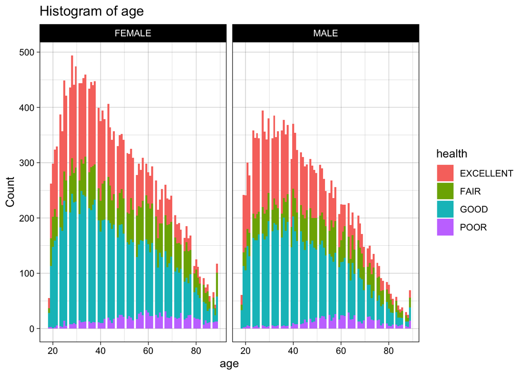

```r
library(ggplot2)
#distribution of age
ggplot(happy) +
  geom_histogram( aes(age, fill =health),binwidth =0.8,alpha = 1, bins =3000,position = "stack")+facet_grid(~sex, scales="free", space="free")+
labs(title="Histogram of age", x="age", y="Count")+theme_linedraw()
```

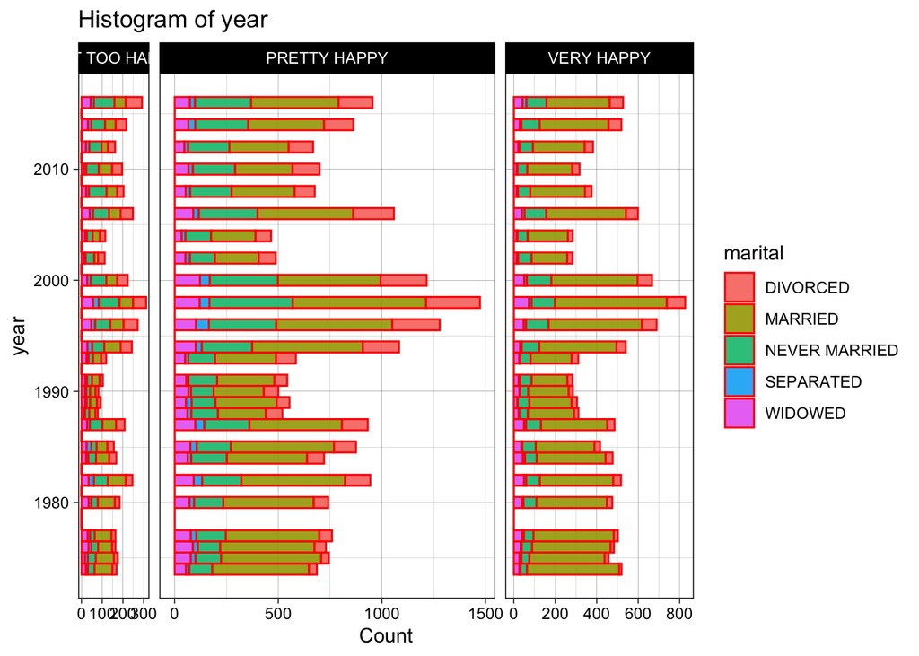

```r
#distribution for year
p<-ggplot(happy)
h<-p+geom_histogram(mapping =aes(year,fill=marital),col="red",binwidth =1 ,alpha = .9, bins =30,position = "stack")
c<-h+theme_linedraw()+labs(title="Histogram of year", x="year", y="Count")+facet_grid(~happy, scales="free", space="free")+coord_flip()
c
```

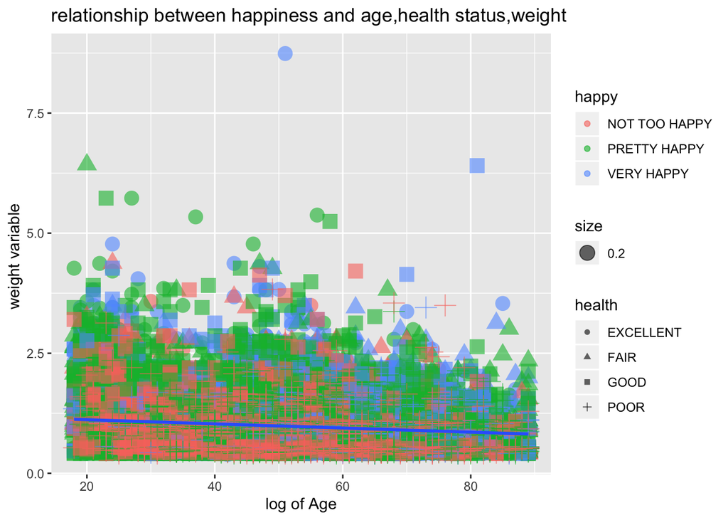

```r
#relationship between age wtssal and happy
ggplot(happy,aes(x=age,y=wtssall))+geom_point(mapping=aes(color=happy,shape=health,size=0.2),alpha = .6)+ geom_smooth(method = "lm")+
  xlab("log of Age") + ylab("weight variable ") + ggtitle("relationship between happiness and age,health status,weight")
```

We learned the relationship between happiness and age, year, health status, maritalstatus, weight variable, sex, and the opinion of family income from the above plots. We also wonder the relationship of the opinion of family income, sex, and happiness.

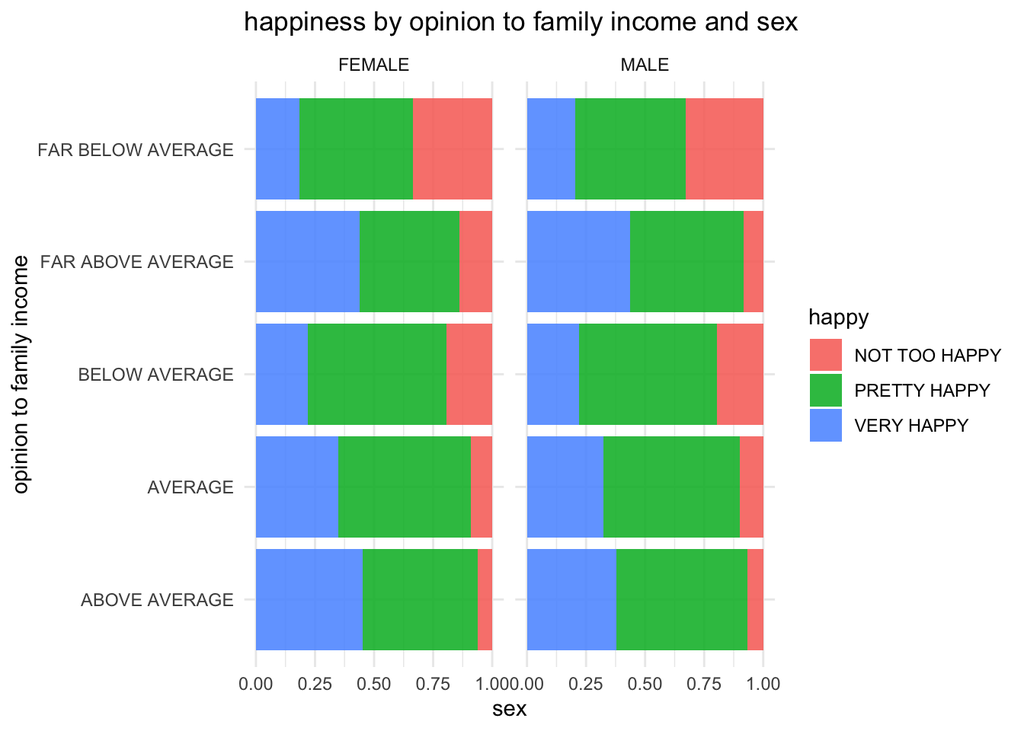

```r
#relationship between happy and finrela
ggplot(happy,aes(x=finrela,fill=happy)) + geom_bar(position="fill",,alpha = .9)+
theme_minimal()+coord_flip()+facet_grid(~sex)+xlab("opinion to family income") + ylab("sex") + ggtitle("happiness by opinion to family income and sex ")
```

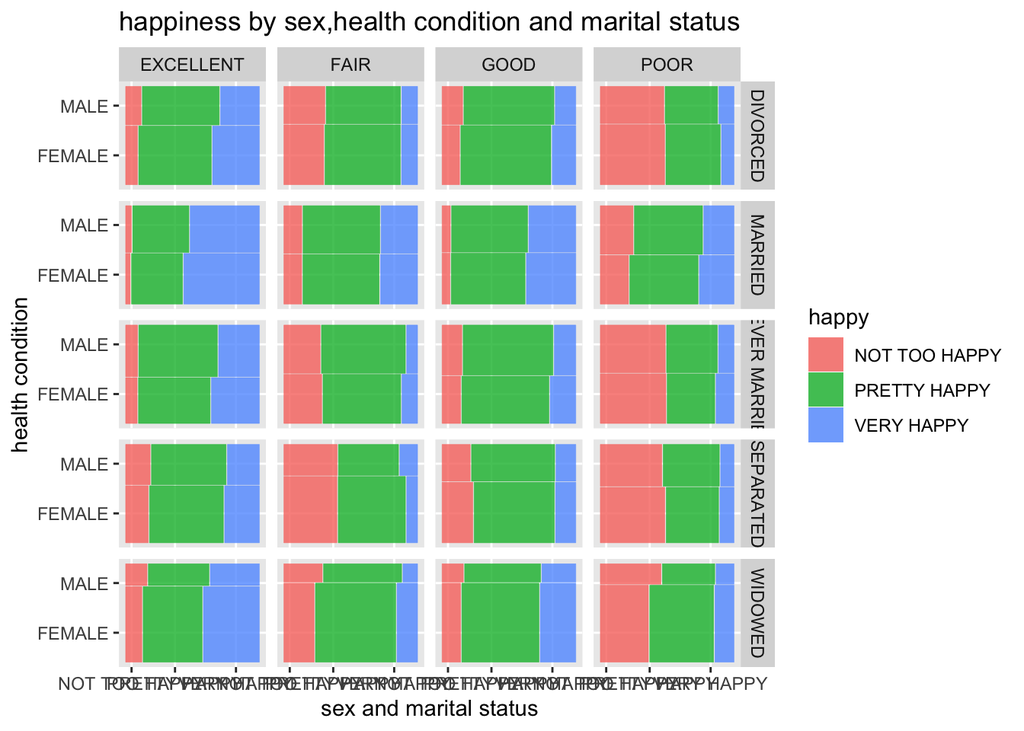

```r
#relationship between sex and marital, health and happiness
library(ggmosaic)
ggplot(data = happy) +
  geom_mosaic(aes(x= product(sex), fill=happy)) +
  facet_grid(marital~health)+coord_flip()+xlab("health condition") + ylab("sex and marital status") + ggtitle("happiness by sex,health condition and marital status  ")
```

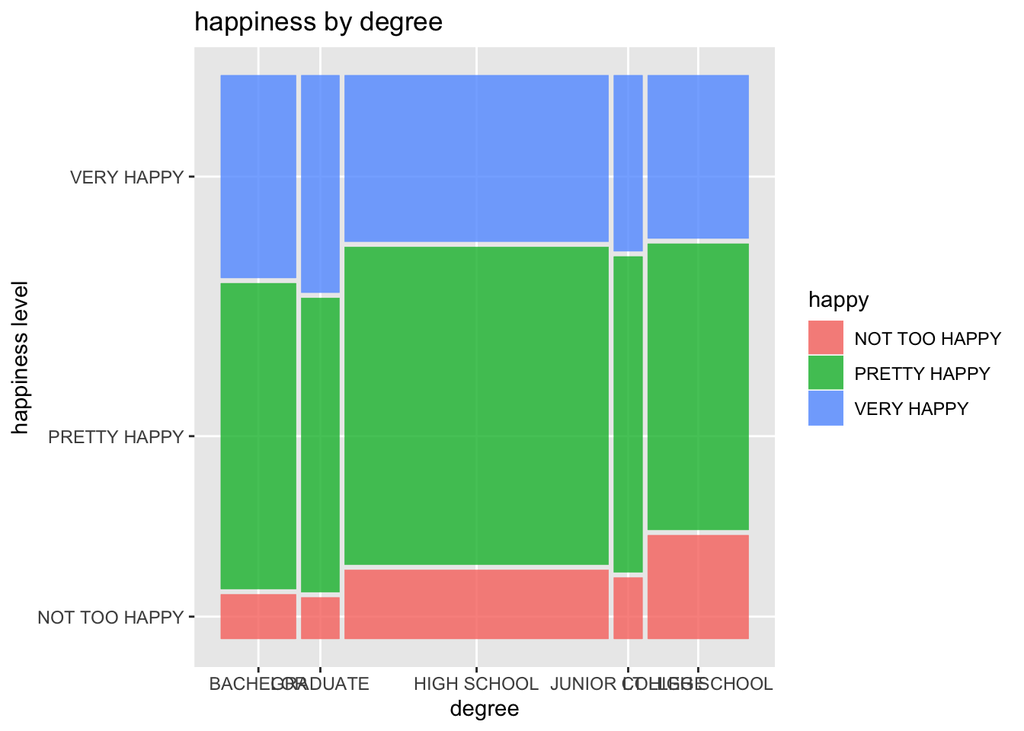

```r
ggplot(data = happy) +
  geom_mosaic(aes(x= product(degree), fill=happy))+xlab("degree") + ylab("happiness level") + ggtitle("happiness by degree ")
```

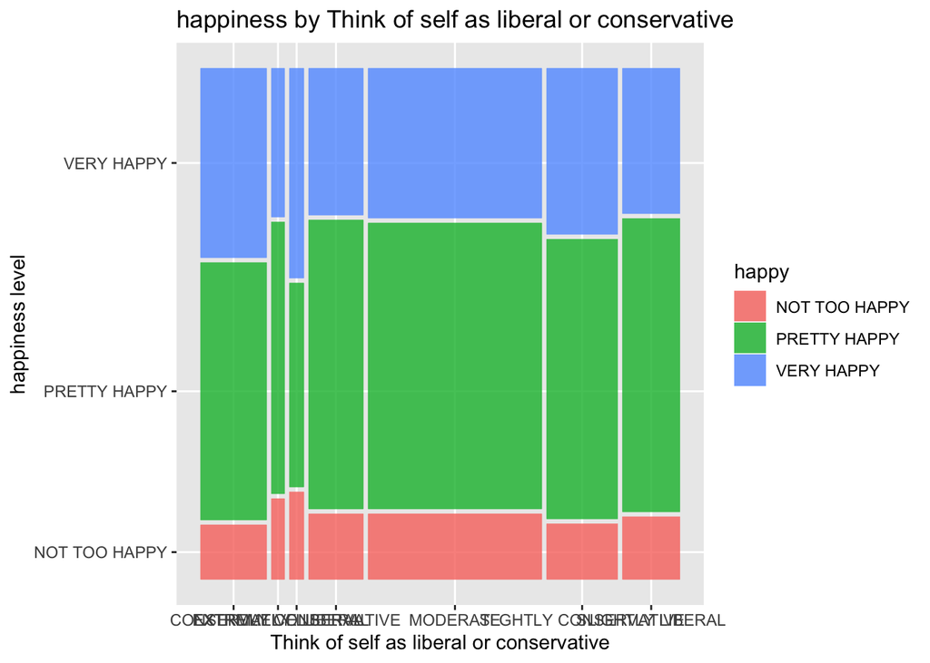

```r
ggplot(data = happy) +
  geom_mosaic(aes(x= product(polviews), fill=happy))+xlab("Think of self as liberal or conservative") + ylab("happiness level") + ggtitle("happiness by Think of self as liberal or conservative ")
```

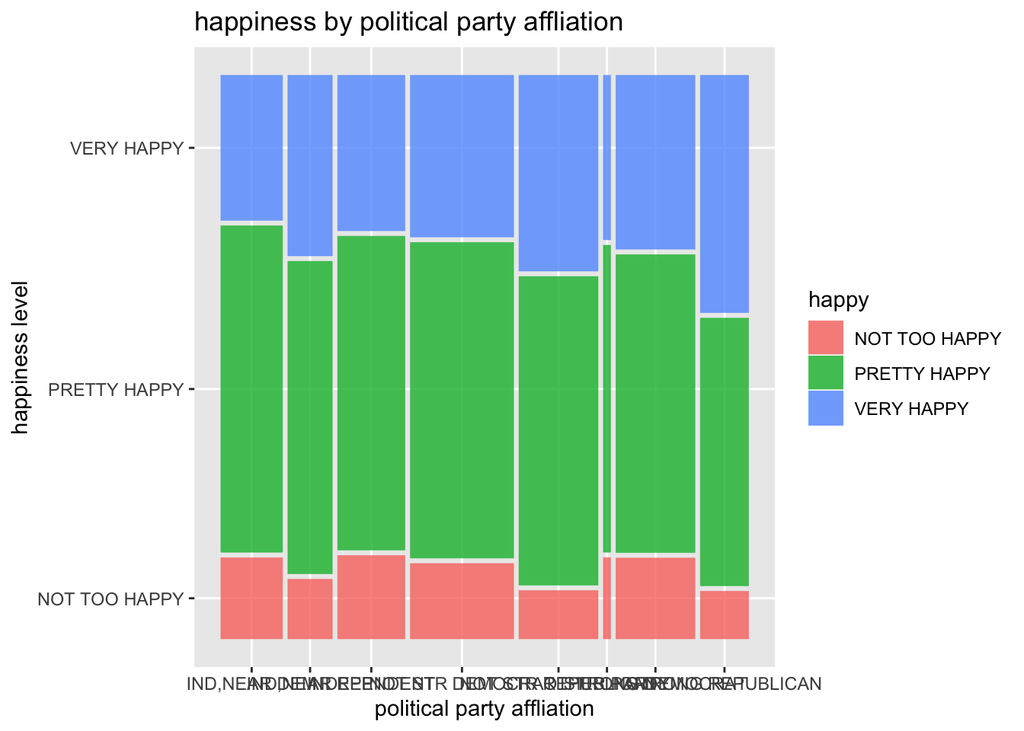

```r
ggplot(data = happy) +
  geom_mosaic(aes(x= product(partyid), fill=happy))+xlab("political party affliation") + ylab("happiness level") + ggtitle("happiness by political party affliation ")
```